# Introduction into trees drawing

# R

```python
%load_ext rpy2.ipython
```

```python
%%R --type=cairo
library(ape)
library(ggtree)
```

## Introduction to `ape` library

### 1. Read our first tree in Newick format

```python
%%R --type=cairo
simpletree <- ape::read.tree(text = "(((A,B), (C,D)), E);")
simpletree
```

```
Phylogenetic tree with 5 tips and 4 internal nodes.

Tip labels:
  A, B, C, D, E

Rooted; no branch lengths.
```

### 2. Plot our tree

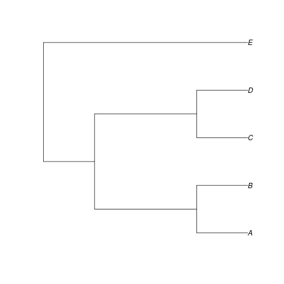

```python
%%R --type=cairo
ape::plot.phylo(simpletree)
```

Plot the same three but as unrooted:

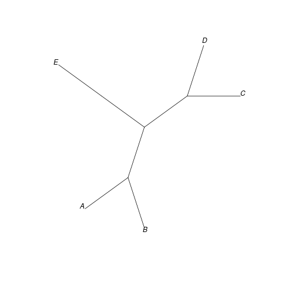

```python
%%R --type=cairo
ape::plot.phylo(simpletree, type="unrooted")
```

### 3. Save our picture

Saving in png

```python
%%R --type=cairo
png("results/simpletree.png") # open device for plotting
ape::plot.phylo(simpletree) # plotting
dev.off() # close our device and save file
```

```python
%%R --type=cairo
png("results/simpletree.svg")
ape::plot.phylo(simpletree)
dev.off()
```

### 4. Load tree

```python
%%R --type=cairo
tree_of_life <- ape::read.tree("https://www.jasondavies.com/tree-of-life/life.txt")
tree_of_life
```

```
Phylogenetic tree with 191 tips and 190 internal nodes.

Tip labels:
  Escherichia_coli_EDL933, Escherichia_coli_O157_H7, Escherichia_coli_O6, Escherichia_coli_K12, Shigella_flexneri_2a_2457T, Shigella_flexneri_2a_301, ...
Node labels:
  , Bacteria, 66, 74, 98, 82, ...

Rooted; includes branch lengths.
```

### 5. Tree plotting

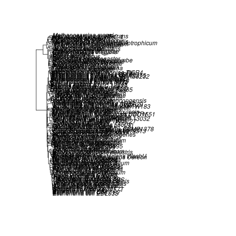

```python
%%R --type=cairo
ape::plot.phylo(tree_of_life)
```

We can plot the same tree using function from standard package

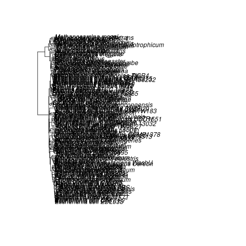

```python
%%R --type=cairo
plot(tree_of_life)
```

Let’s prettify our plot (by text size reduction: parameter `cex`)

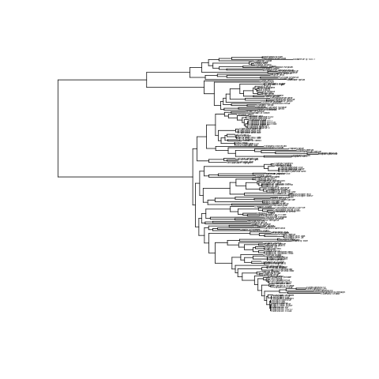

```python
%%R --type=cairo
ape::plot.phylo(tree_of_life, cex = 0.2)
```

Save results:

```python
%%R --type=cairo
png(filename = "results/treeOfLife.png", width = 20, height = 20, units = "cm", res = 600)
ape::plot.phylo(tree_of_life, cex = 0.2)
dev.off()
```

### 6. Plotting tree as unrooted and radial

Plot the same tree but make it unrooted

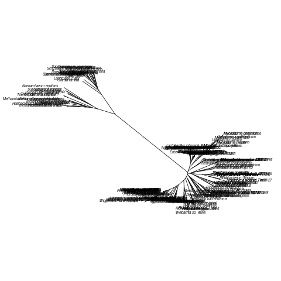

```python
%%R --type=cairo
plot.phylo(tree_of_life, type = "unrooted", no.margin = T, cex=0.5)
```

Plot tree in radial format

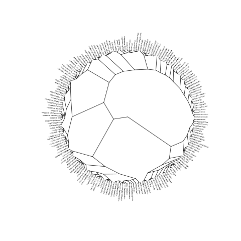

```python
%%R --type=cairo
ape::plot.phylo(tree_of_life, type = "radial", cex=0.2)
```

## Introduction to `ggtree` library

### 7. Plot our tree using ggtree with minimal settings

There is no information about taxa names

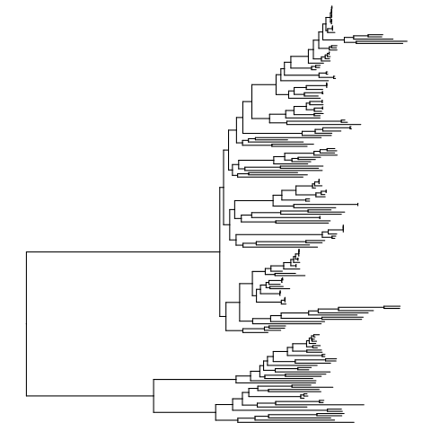

```python
%%R --type=cairo
ggtree(tree_of_life)
```

### 8. Display information about taxa names

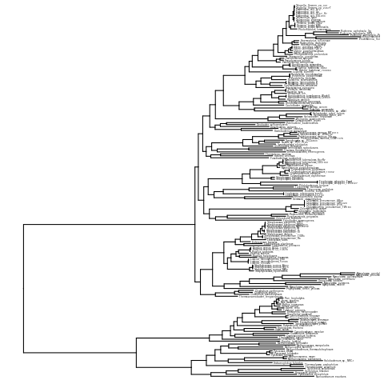

```python
%%R --type=cairo
ggtree(tree_of_life) + geom_tiplab(size = 1)
```

### 9. Plot circular tree

```
R[write to console]: Scale for 'y' is already present. Adding another scale for 'y', which will
```

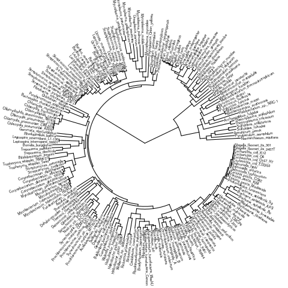

```python
%%R --type=cairo
ggtree(tree_of_life) + layout_circular() + geom_tiplab(size = 2)
```

**Be careful!** The order of commands is important for correct visualization. If we break it, we can obtain wrong results

```
R[write to console]: Scale for 'y' is already present. Adding another scale for 'y', which will
```

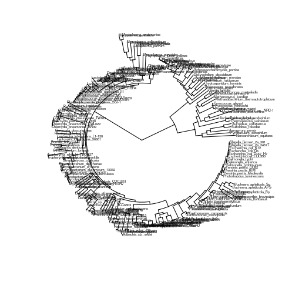

```python
%%R --type=cairo
ggtree(tree_of_life) + geom_tiplab(size = 2) + layout_circular()
```

Check whether label is human

```python
%%R --type=cairo
is.human <- tree_of_life$tip.label == "Homo_sapiens"
is.human
```

```
  [1] FALSE FALSE FALSE FALSE FALSE FALSE FALSE FALSE FALSE FALSE FALSE FALSE
 [13] FALSE FALSE FALSE FALSE FALSE FALSE FALSE FALSE FALSE FALSE FALSE FALSE
 [25] FALSE FALSE FALSE FALSE FALSE FALSE FALSE FALSE FALSE FALSE FALSE FALSE
 [37] FALSE FALSE FALSE FALSE FALSE FALSE FALSE FALSE FALSE FALSE FALSE FALSE
 [49] FALSE FALSE FALSE FALSE FALSE FALSE FALSE FALSE FALSE FALSE FALSE FALSE
 [61] FALSE FALSE FALSE FALSE FALSE FALSE FALSE FALSE FALSE FALSE FALSE FALSE
 [73] FALSE FALSE FALSE FALSE FALSE FALSE FALSE FALSE FALSE FALSE FALSE FALSE
 [85] FALSE FALSE FALSE FALSE FALSE FALSE FALSE FALSE FALSE FALSE FALSE FALSE
 [97] FALSE FALSE FALSE FALSE FALSE FALSE FALSE FALSE FALSE FALSE FALSE FALSE
[109] FALSE FALSE FALSE FALSE FALSE FALSE FALSE FALSE FALSE FALSE FALSE FALSE
[121] FALSE FALSE FALSE FALSE FALSE FALSE FALSE FALSE FALSE FALSE FALSE FALSE
[133] FALSE FALSE FALSE FALSE FALSE FALSE FALSE FALSE FALSE FALSE FALSE FALSE
[145] FALSE FALSE FALSE FALSE FALSE FALSE FALSE FALSE FALSE FALSE FALSE FALSE
[157] FALSE FALSE FALSE FALSE FALSE FALSE FALSE FALSE FALSE FALSE  TRUE FALSE
[169] FALSE FALSE FALSE FALSE FALSE FALSE FALSE FALSE FALSE FALSE FALSE FALSE
[181] FALSE FALSE FALSE FALSE FALSE FALSE FALSE FALSE FALSE FALSE FALSE
```

Check index of this element

```python
%%R --type=cairo
which(tree_of_life$tip.label == "Homo_sapiens")
```

```
[1] 167
```

### 10. Highlight some group on the picture

```
R[write to console]: Scale for 'y' is already present. Adding another scale for 'y', which will
```

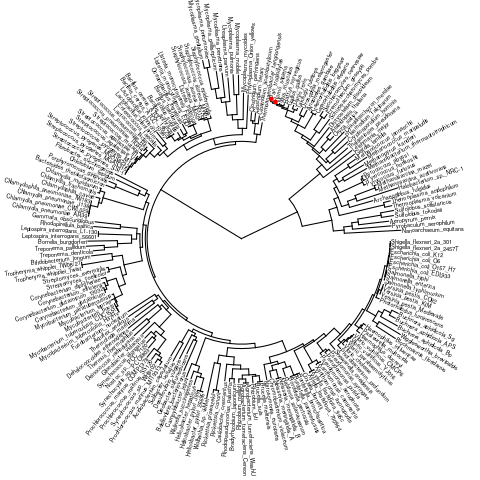

```python
%%R --type=cairo
tree_of_life <- groupOTU(tree_of_life, c("Homo_sapiens", "Pan_troglodytes"))
ggtree(tree_of_life) + layout_circular() +
geom_tiplab2(size = 2) + geom_tippoint(aes(alpha = group), col = "red") +
scale_color_manual(values = c(0,1), aesthetics = "alpha") +
theme(legend.position = 'null')
```

```
R[write to console]: Scale for 'y' is already present. Adding another scale for 'y', which will
```

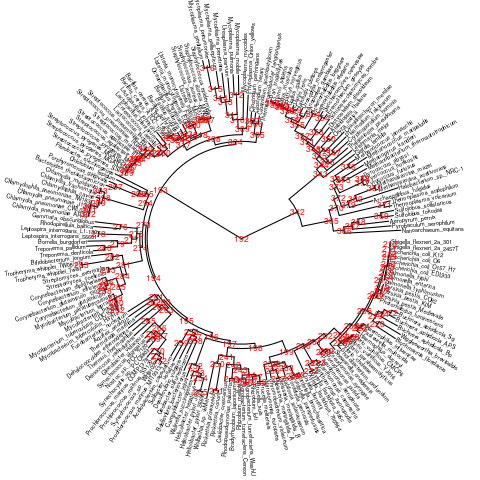

```python
%%R --type=cairo
ggtree(tree_of_life) + layout_circular() + geom_tiplab(size = 2) +
geom_text2(aes(subset=!isTip, label=node), size = 3, col = "red")
```

Color some part of the tree by its node

```
R[write to console]: Scale for 'y' is already present. Adding another scale for 'y', which will
```

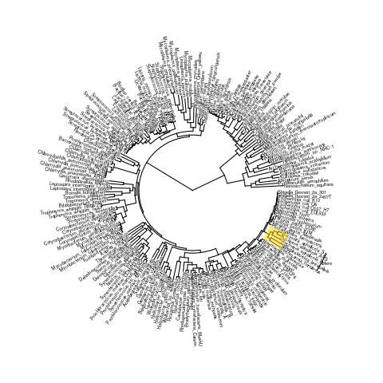

```python
%%R --type=cairo
ggtree(tree_of_life) + layout_circular() + geom_tiplab2(size = 2) +
geom_hilight(node = 219, fill = "gold") +
geom_cladelabel(node = 219, label = "Here", fontsize = 2, offset = 1)
```

# Python

```python
import requests
import matplotlib.pyplot as plt
from io import StringIO
from Bio import Phylo
import random
from ete3 import Tree, TreeStyle
```

## Bio::Phylo

### 11. Data Loading

Look at the content of the downloaded file. Here we have a tree in Newick format.

```python
requests.get('https://www.jasondavies.com/tree-of-life/life.txt').text
```

```
'(((((((((((((((((((Escherichia_coli_EDL933:0.00000,Escherichia_coli_O157_H7:0.00000)96:0.00044,((Escherichia_coli_O6:0.00000,Escherichia_coli_K12:0.00022)76:0.00022,(Shigella_flexneri_2a_2457T:0.00000,Shigella_flexneri_2a_301:0.00000)100:0.00266)75:0.00000)100:0.00813,((Salmonella_enterica:0.00000,…
```

Load our tree data as a Python string and parse it with the help of `StringIO`

```python
raw_tree = StringIO(requests.get('https://www.jasondavies.com/tree-of-life/life.txt').text)
```

Convert loaded data into the tree object

```python
tree1 = Phylo.read(raw_tree, "newick")
tree1
```

```
Tree(rooted=False, weight=1.0)
```

### 12. Drawing with pseudographics

Draw this tree with pseudographics (in asscii format)

**Note:** Biopython is bad for drawing

```python
Phylo.draw_ascii(tree1)
```

```
                             , Escherichia_coli_EDL933
                             | Escherichia_coli_O157_H7
                             , Escherichia_coli_O6
                             | Escherichia_coli_K12
                             , Shigella_flexneri_2a_2457T
                             | Shigella_flexneri_2a_301
                             , Salmonella_enterica
                             | Salmonella_typhi
                             | Salmonella_typhimurium
                             , Yersinia_pestis_Medievalis
                             , Yersinia_pestis_KIM
                            ,| Yersinia_pestis_CO92
                            ||
                            || Photorhabdus_luminescens
                            ||
                            ||   ___ Blochmannia_floridanus
                            || ,|
                            || ||____ Wigglesworthia_brevipalpis
                            ||_|
                            |  |___ Buchnera_aphidicola_Bp
                            |  |
                            |  | , Buchnera_aphidicola_APS
                            |  |_|
                            |    | Buchnera_aphidicola_Sg
                            |, Pasteurella_multocida
                            ||
                            || Haemophilus_influenzae
                           ,||
                           ||| Haemophilus_ducreyi
                           ||
                           ||, Vibrio_vulnificus_YJ016
                           |||
                           ||| Vibrio_vulnificus_CMCP6
                          ,|||
                          ||,| Vibrio_parahaemolyticus
                          ||||
                          |||| Vibrio_cholerae
                          |||
                         ,||| Photobacterium_profundum
                         |||
```

[output cut: 308 more lines]

```
                    | |___|
                    |,|   | Methanococcus_jannaschii
                    |||
                    |||    , Pyrococcus_horikoshii
                    |||   ,|
                    |||___|| Pyrococcus_abyssi
                     |    |
                     |    | Pyrococcus_furiosus
                     | ____ Archaeoglobus_fulgidus
                     ||
                      |  _______ Halobacterium_sp._NRC-1
                      |_|
                        |   , Methanosarcina_acetivorans
                        |___|
                            | Methanosarcina_mazei
```

### 13. Plotting tree as a picture

Plot out tree as a picture and save it.

Parameter: `do_show=False` allows to save this picture into the file (otherwise it will be empty)

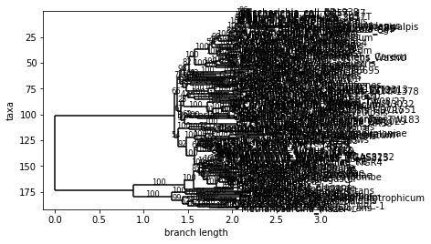

```python
Phylo.draw(tree1, do_show=False);
plt.savefig("results/py_tree1_phylo.svg")
plt.savefig("results/py_tree1_phylo.png")
```

**Biopython advantage:** we can convert phylogenic tree from one format to another

```python
tree1 = tree1.as_phyloxml()
Phylo.write(tree1, "results/tree1.xml", "phyloxml")
```

```
1
```

[figure not shown]

### 14. Picture tunning to make it more readable

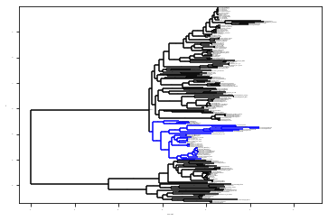

```python
tree1.clade[0, 1].color = "blue"
plt.rc('font', size=1)
plt.figure(figsize=(24,12))
Phylo.draw(tree1, do_show = False)
plt.savefig("results/py_tree1_phylo_blue.png", dpi=600)
```

[figure not shown]

## ETE (ETE3)

### 15. Load our tree

```python
raw_tree = requests.get('https://www.jasondavies.com/tree-of-life/life.txt').text
```

Convert loaded data into the tree object

```python
tree2 = Tree(raw_tree, format=1)
tree2
```

```
Tree node '' (0x7f94cb46a3d)
```

### 16. Plotting tree as a picture

```python
tree2.render("results/py_tree2_ete3.pdf");
```

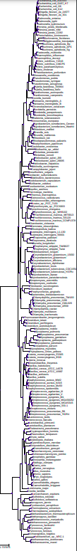

**TreeStyle** allows to draw some interesting graphs

```python
circular_style = TreeStyle()
circular_style.mode = "c"
circular_style.scale = 20
tree2.render("results/py_tree2_ete3_circ.pdf", tree_style=circular_style);
```

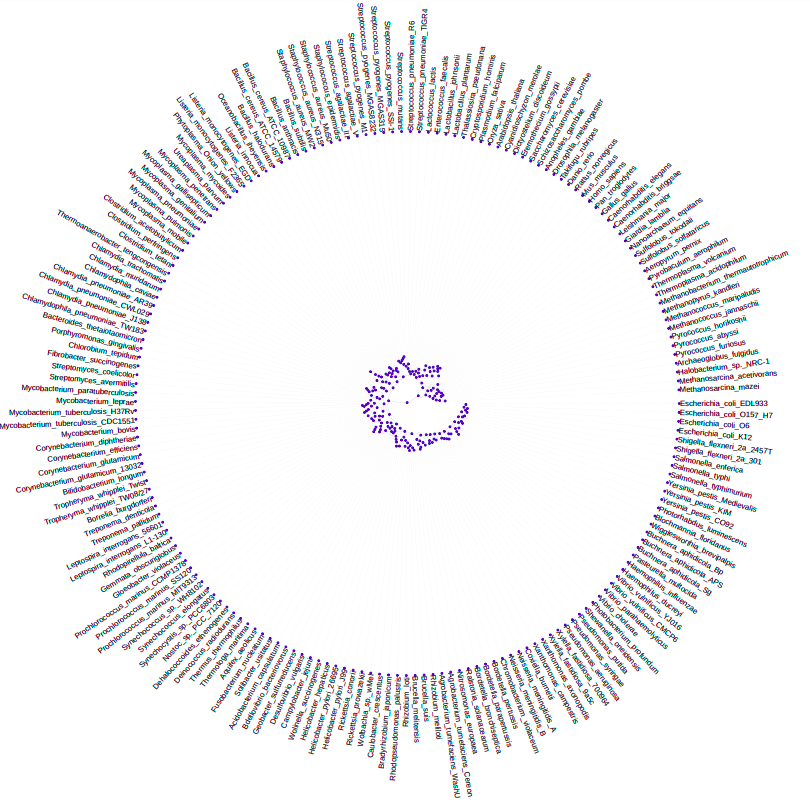

### 17. Tree prunning

Prune some piece of the tree for better visualization and interpretation.

Here we sample random 42 leaves from the tree

```python
ss = random.sample(tree2.get_leaf_names(), 42)
tree2.prune(ss)
tree2.render("results/py_tree2_ete3_random.pdf");
```

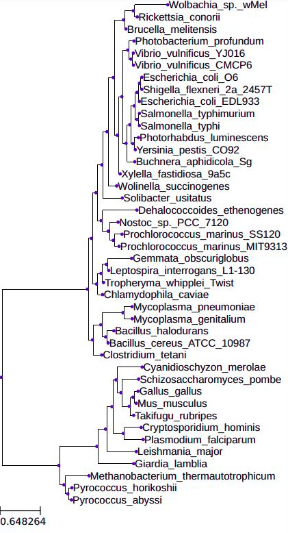